GenAI Beyond the Basics: Advanced Concepts for Actuaries

Simon Hatzesberger (simon.hatzesberger@gmail.com)

*4 December 2025*

# Table of Contents

**1. Introduction and Key Takeaways**

**2. Using LLMs via API**

**3. Structured Outputs**  
3.1 Concept and Purpose  
3.2 Use Case: Structured Data Extraction from Policy Documents  
3.3 Further Applications and Resources

**4. Function Calling**  
4.1 Concept and Purpose  
4.2 Use Case: Mortality Data Retrieval from Database via Function Calling  
4.3 Further Applications and Resources

**5. Fine‑Tuning**  
5.1 Concept and Purpose  
5.2 Use Case: Improving Car Damage Classification by Fine-Tuning Vision-Enabled LLMs  
5.3 Further Applications and Resources

**6. Retrieval‑Augmented Generation**  
6.1 Concept and Purpose  
6.2 Use Case: Extracting KPIs from Annual Reports with RAG  
6.3 Further Applications and Resources

**7. Outlook**  
7.1 Combining GenAI Building Blocks: Real-Time Hail-Claim Assessment  
7.2 Multi-Agent Systems: From Single Models to Collaborative AI Agents

# 1. Introduction and Key Takeaways

This Jupyter Notebook introduces *advanced* concepts and techniques in Generative AI (GenAI) that go well beyond a simple chat interface such as ChatGPT. We will explore how actuaries can integrate and extend modern Large Language Model (LLM) capabilities through **Fine‑Tuning**, **Structured Outputs**, **Retrieval‑Augmented Generation (RAG)**, and **Function Calling**. These techniques expand what an LLM can do, allow you to tailor it to specialised actuarial tasks, and help you embed GenAI seamlessly into production workflows.

Because GenAI is rapidly reshaping content creation, automation, and decision‑support, a solid grasp of the tools "under the hood" has become indispensable for actuarial work. This notebook targets actuaries and data scientists who already have basic Python skills and want to deepen their technical understanding of GenAI's programmatic power.

#### Core Techniques Covered

- **Structured Outputs** — Enforce responses to be in predefined JSON formats for downstream processing.
- **Function Calling** — Let the model trigger deterministic functions (e.g. database queries, calculations) so that "thinking" and "doing" work hand in hand.
- **Fine‑Tuning** — Refine a pretrained model with domain‑specific data to improve accuracy and relevance.
- **Retrieval‑Augmented Generation** — Inject external knowledge into model queries for richer, contextual responses.

#### Key Takeaways Upon Completing This Notebook

- You will know how to call OpenAI's LLMs via API from Python and integrate them into actuarial workflows.
- You will be able to determine when Structured Outputs, Function Calling, Fine‑Tuning, RAG, or a combination thereof offers the most effective solution to a problem.
- You will experience hands‑on actuarial use cases and receive reusable, adaptable code snippets for each technique.
- You will leave with practical pointers to further applications, learning resources, and best‑practice guidelines.

The notebook is organised as follows:  
Section 2 (Using LLMs via API) covers API fundamentals and shows how to send your first prompts. Sections 3 to 6 dive deeply into each core technique (Structured Outputs, Function Calling, Fine‑Tuning, and Retrieval‑Augmented Generation). Every section follows the same rhythm: *Concept and Purpose → Use Case → Further Applications and Resources*. Finally, Section 7 (Outlook) looks ahead to upcoming GenAI trends such as LLM-based agents.

# 2. Using LLMs via API

Most actuaries first encounter Generative AI (GenAI) through **web‑based chat interfaces** such as ChatGPT – the classic browser window is shown in the screenshot below.

[figure not shown]

*ChatGPT accessed through its standard web interface.*  
*[Source: [chatgpt.com](https://chatgpt.com/)]*

When we access Large Language Models **programmatically via API**, we unlock capabilities that go far beyond the web chat:

- *Seamless integration* — call GenAI directly from actuarial (Python) workflows.
- *Massive scale* — issue thousands of requests concurrently without throttling your own productivity.
- *Full conversational control* — tune instructions, temperature, and other parameters to steer tone, depth, and format of the response.
- *Data synergy* — combine the model's reasoning with in‑house datasets, downstream code, or external knowledge bases.

Broader topics – each worthy of its own deep‑dive – that **fall outside the scope of this notebook** are as follows:

- *Mathematical/Technical Foundations of LLMs* — tokenisation, transformer blocks, training objectives, and optimisation.
- *Governance and compliance* considerations for enterprise use of GenAI.
- Deep‑dive *prompt‑engineering* theory (beyond the practical tips we provide on the way).
- *Production deployment & MLOps* topics such as monitoring, model versioning, and automation of updates.

For those areas, please consult specialized courses or official documentation—our priority here is to equip you with practical OpenAI API skills as efficiently as possible.

**Note**

Everything you see in this notebook is demonstrated with OpenAI's models, yet the underlying ideas – authentication, prompt design, Structured Outputs, Function Calling, Fine-Tuning, Retrieval‑Augmented Generation – apply almost one‑to‑one to other leading providers such as Anthropic Claude, Mistral, Google Gemini or open‑source models served through an API.

#### Python environment

All cells below assume a local or cloud Python environment in which the packages listed in the file `requirements.txt` have been installed.  
If you have not done so yet, run

```
pip install -r requirements.txt
```

(or use your favourite environment manager such as *pipx*, *conda*, *poetry* or *virtualenv*) before you execute the rest of the notebook.

```python
# Uncomment the next line if you need to (re)install the packages directly
# %pip install -r requirements.txt
```

First, we load all necessary libraries.

```python
# Standard library imports
import os
import logging
import json
import base64
import re
import sqlite3
from urllib.parse import urlparse, unquote

# Typing utilities
from typing import List, Optional, Literal

# OpenAI client
from openai import OpenAI

# Numerical and tabular data handling
import numpy as np
import pandas as pd

# Configure pandas display options for enhanced readability
pd.set_option('display.expand_frame_repr', False)
pd.set_option('display.max_colwidth', 3000)
pd.set_option('display.max_columns', None)

# Plotting
import matplotlib.pyplot as plt

# Machine learning metrics and model selection
from sklearn.metrics.pairwise import cosine_similarity
from sklearn.model_selection import train_test_split
from sklearn.metrics import accuracy_score

# Progress bars
from tqdm import tqdm

# HTTP requests
import requests

# PDF and image processing
import fitz
from PIL import Image

# Data validation
from pydantic import BaseModel

# Local data and API helpers
import kagglehub
```

#### Authenticating with the OpenAI API

Every request to the OpenAI back‑end must be signed with a **secret API key**.  
You can create one in your [OpenAI dashboard](https://platform.openai.com/account/api-keys) and revoke it at any time.

There are two common ways to make the key available to your code:

1. **Environment variable** (recommended for production)

   ```
   export OPENAI_API_KEY=sk-...
   ```

2. **Text file** in the project folder that is *never* committed to version control (e.g. `openai_api_key.txt`).

The helper function below transparently supports *both* variants.

```python
def load_openai_api_key(file_path: str = "openai_api_key.txt", env_var: str = "OPENAI_API_KEY") -> str:
    """Return an OpenAI API key either from an environment variable or a local file."""
    key = os.getenv(env_var)
    if key:
        return key.strip()
    if os.path.exists(file_path):
        with open(file_path, "r", encoding="utf-8") as f:
            return f.read().strip()
    raise FileNotFoundError(
        "No OpenAI API key found. Set the environment variable '{}' or create the file '{}'".format(env_var, file_path)
    )

# Initialise the global OpenAI client once
api_key = load_openai_api_key()
client = OpenAI(api_key=api_key)
```

Below is a **minimal Python example** demonstrating how to call an OpenAI LLM via the API. We use the `client.responses.create()` method to:

1. Specify which model to invoke (`gpt-4.1-mini`),
2. Pass in a simple actuarial prompt, and
3. Print out the model's reply.

```python
# Define the default model to be used for OpenAI API calls
MODEL_DEFAULT = "gpt-4.1-mini"

response = client.responses.create(
    model=MODEL_DEFAULT,
    input="In one sentence, explain how the loss ratio is calculated for an auto-insurance portfolio."
)
print(response.output_text)
```

```
The loss ratio for an auto-insurance portfolio is calculated by dividing the total incurred losses (claims paid plus loss reserves) by the total earned premiums over a specific period.
```

This API call pattern will reappear throughout the notebook—often extended with the additional code required for each GenAI technique under discussion.

**Note**

Each API call incurs a charge based on the number of tokens processed (input + output), where one token is roughly ¾ of a word. See OpenAI’s [pricing page](https://openai.com/pricing) for current rates. Ensure your account balance is positive before making requests to avoid failed calls.

#### Instructions matter – an actuarial example

The `instructions` parameter functions like the system message at the start of a conversation, defining the assistant’s tone, depth, and focus. In this example, we ask the model:

**What is the Solvency Capital Requirement (SCR) and why is it important?**

in two ways:

1. **Default prompt** (no special instructions)
2. **Guided role prompt** that frames the assistant as "a senior actuary" who must explain the SCR in plain English for a new analyst, keep it brief, and end with one practical takeaway.

```python
question = "What is the Solvency Capital Requirement (SCR) and why is it important?"

# Variant 1 – default prompt
response_plain = client.responses.create(
    model=MODEL_DEFAULT,
    input=question
)

# Variant 2 – with simple role instructions
role_instructions = (
    "You are a senior actuary. Explain the SCR in plain English for a new analyst, "
    "keep it brief, and end with one practical takeaway."
)
response_role = client.responses.create(
    model=MODEL_DEFAULT,
    input=question,
    instructions=role_instructions
)

print("——— Without instructions ———\n", response_plain.output_text)
print("\n——— With instructions ———\n", response_role.output_text)
```

```
——— Without instructions ———
 The **Solvency Capital Requirement (SCR)** is a key regulatory metric used primarily in the insurance industry, especially under the **Solvency II Directive** in the European Union. It represents the amount of capital that an insurance company must hold to ensure that it can meet its obligations ov…

### Detailed Explanation:

- **Definition:**
  The SCR is the minimum capital an insurer needs to cover its risk exposures, including underwriting risk, market risk, credit risk, and operational risk. It reflects the capital requirement to withstand significant losses in adverse scenarios.

- **Purpose and Importance:**
  - **Policyholder Protection:** The SCR ensures that insurers have enough financial resources to pay claims, providing security and confidence to policyholders.
  - **Risk Sensitivity:** The SCR calculation considers the specific risk profile of the company, meaning it is risk-based rather than a fixed amount, promoting better risk management and financial stability.
  - **Regulatory Compliance:** Meeting the SCR is mandatory under regulations like Solvency II. Failure to meet SCR requirements can trigger supervisory intervention or restrictions on the insurer's activities.
  - **Market Confidence:** Adequate capital reserves bolster the confidence of investors, customers, and regulators, enhancing the insurer’s reputation and stability in the financial markets.
  - **Encourages Better Risk Management:** By linking capital requirements to risk profiles, it encourages insurers to identify, measure, and manage risks more effectively.

### Summary:
The **Solvency Capital Requirement (SCR)** is the amount of capital an insurer must hold to remain solvent with a 99.5% confidence over one year, reflecting its risk profile. It is crucial for protecting policyholders, ensuring regulatory compliance, maintaining market stability, and promoting prude…

——— With instructions ———
 The Solvency Capital Requirement (SCR) is the amount of money an insurance company needs to hold to stay financially strong and cover its risks over the next year with high confidence. It acts like a safety cushion to ensure the company can pay claims even in tough situations, such as big losses or…

Practically, the SCR helps protect policyholders by making sure the insurer won't run out of money when they need to pay. For you as an analyst, always remember: the SCR is a key measure of the company’s financial health and risk exposure.
```

Another advantage of the `instructions` parameter is that it enables you to establish a **consistent task definition** across multiple calls, while supplying different **inputs** – such as text, image representations, or numeric data – via the `input` parameter (see, for instance, the use case in Subsection 5.2).

# 3. Structured Outputs

## 3.1 Concept and Purpose

LLMs are designed to produce human-readable prose, yet many actuarial workflows require **machine-readable data** that drops straight into code, spreadsheets, or databases. The concept of *Structured Outputs* solves this by enforcing the model to return a response that follows a **predefined JSON schema** rather than free-form text. When the LLM reliably fills named fields with well-specified data types, the result can be parsed deterministically – removing the need for fragile regex parsers and ad-hoc clean-up scripts.

**Note**

OpenAI's `text_format` parameter – successor to the earlier `response_format` parameter – is the recommended way to apply Structured Outputs. Combined with *Pydantic* (or a comparable schema library), it ensures end-to-end adherence to your JSON schema. The same workflow applies to other providers: declare the schema, embed its definition in the prompt, and instruct the model to honour it.

#### Why It Matters for Actuaries

- **Repeatability** – pricing, reserving, and reporting pipelines receive the same field names and formats every run.
- **Interoperability** – JSON can be consumed by spreadsheets, BI dashboards, or actuarial software (e.g., Prophet, ResQ) with no extra transformation layer.
- **Expressiveness** – nested objects and optional fields capture complex insurance concepts such as multi-vehicle policies, layered treaties, or cash-flow waterfalls.

#### How Structured Outputs Work

1. **Define the schema** – create a *Pydantic* model or JSON schema that represents the desired output.
2. **Send prompt + schema** – include the schema (or a textual description of it) in the prompt and set `text_format`.
3. **LLM validation** – the model fills in the fields and self-checks before responding.
4. **Parse and use** – your application loads the JSON into a data class and feeds it straight into downstream code.

## 3.2 Use Case: Structured Data Extraction from Policy Documents

In this use case we ask an LLM to analyse a **synthetic automobile insurance policy** from the open-access [RISCBAC corpus](https://huggingface.co/datasets/davebulaval/RISCBAC) — a dataset of 10 000 bilingual (FR/EN) contracts generated from the Québec standard form.

A RISCBAC auto policy embeds a variety of structured facts that we'll extract in this notebook, for example:

- Policy and endorsement numbers
- Insured's personal details (name, address, date of birth)
- Vehicle information (VIN, make, model, year)
- Coverage sections with limits and deductibles
- Premium amounts by coverage type
- Policy effective and expiry dates

Our task is to extract specified data fields from the narrative policy and format them as a **machine-readable JSON object**, which in a real-world workflow could then be consumed by downstream code.

The next cell simply loads the *first* English contract from `riscbac_en_first10.jsonl` and prints the raw text content.

```python
# Set the desired row number (1-based index)
row_number = 1  # Change this to the row (1-10) you want

# Path to your JSONL file
file_path = "riscbac_en_first10.jsonl"

# Read and parse the JSONL file
with open(file_path, "r", encoding="utf-8") as f:
    lines = f.readlines()

data = json.loads(lines[row_number - 1])  # Convert to 0-based index
text_content = data.get("text", "")

print(text_content)
```

```
October 16, 2022


ISSUE
Client N: 382787
Policy / Term:
001 / 12 month

ALWAYS BY YOUR SIDE FOR YOUR INSURANCE

Please find enclosed your insurance documents.
We recommend that you read them carefully to ensure that they are correct.
If an Important Instructions page is included with these documents, please read through it carefully because it contains crucial information regarding your coverage.
Feel free to contact us if you have any questions or comments.

CONTACT US
Customer Service
123 456-7890
1 800 123-4567
Fax: 012 345-6789
service.client@assureur.ca
8 a.m. to 8 p.m.
Monday to Friday
8:30 a.m. to 4 p.m., Saturday
Claims
098 765-4321
1 800 765-4321
24/7 emergency
Legal Assistance
1 800 012-3456
8:30 a.m. to 7 p.m.
Monday to Thursday
8:30 a.m. to 5 p.m., Friday
Your branch
221 B Baker Street
Ville (Province)
A1A 1A1
8:30 a.m. to 5 p.m.
Monday to Friday
assureur.ca
```

[output cut: 2233 more lines]

```
that are installed or meant to be installed permanently in or on the specified vehicle; and
that are used for communicating, reproducing or recording sound or images or both simultaneously, including:
	 - compact disc and DVD players;
	 - personal navigation devices (GPS);
	 - radios, including citizens band, two-way amateur or other radios; and
	 - sound systems.
<###NEW_PAGE###>
ENDORSEMENT(S)
FORMING A PART OF YOUR AUTOMOBILE INSURANCE POLICY
2. Original electronic equipment
The expression ''original electronic equipment'' as used in this endorsement means the electronic equipment:
	 that is installed by the manufacturer or the dealer; and
	 that was included in the original purchase price of the specified vehicle.
All other conditions of the insurance contract remain the same.
<###NEW_PAGE###>
```

We structure this exercise in three progressively stricter stages:

1. **Stage 1 — Free-form extraction**  
   Prompt GPT-4 without a schema and observe the variability.
2. **Stage 2 — Basic flat schema**  
   Supply a minimal Pydantic model to stabilise output.
3. **Stage 3 — Advanced nested schema**  
   Use a comprehensive Pydantic hierarchy to capture full policy complexity.

### Stage 1 — Free-form extraction

In this first experiment, we ask GPT-4 to pull the driver’s last and first names, vehicle details, premium amount, and contract period without any formal schema. Run the cell multiple times and notice:

- Thousands separators may appear or vanish.
- Currency symbols can be included or omitted.
- Sometimes the output is formatted as bullet points and other times as free-form text.

Although each response is human-readable, the format is too inconsistent for reliable downstream parsing.

Note that in all approaches, the extraction prompt goes into the `instructions` parameter, while the policy text to be analysed is passed via the `input` parameter.

```python
instructions_car_insurance_naive = """
You will be given a free-form description of a car insurance contract.
Your job is to extract the driver's last name, the driver's first name, the vehicle, the premium, and the contract period.
"""

contract_information_naive = client.responses.create(
    model="gpt-4.1-nano",
    input=text_content,
    instructions=instructions_car_insurance_naive
)

print(contract_information_naive.output_text)
```

```
Last Name: Craig
First Name: Ryan
Vehicle: Acura RDX 2010
Premium: 1047$ (excluding tax)
Contract Period: From 2022-12-25 to 2023-12-25
```

#### Stage 2 — Basic flat schema

Next, we define a simple Pydantic model `CarInsuranceContract_basic` listing only the required fields—each with an explicit type (string or integer). By setting `text_format=CarInsuranceContract_basic`, the underlying LLM is instructed to return a strictly valid JSON object that conforms to this schema. The result is now fully deterministic and ready for parsing, with (usually) identical output across repeated runs and no ad-hoc cleanup needed.

```python
# 1. Craft class for Structured Output
class CarInsuranceContract_basic(BaseModel):
    driver_last_name: str
    driver_first_name: str
    vehicle_make_and_model: str
    premium: int
    contract_period: str

# 2. Craft a precise instructions prompt for your schema
instructions_car_insurance_basic = """
You will be given a free-form description of a car insurance contract.
Your job is to extract **only** the following fields and return a **strictly valid JSON object** that matches the `CarInsuranceContract_basic` Pydantic schema, without extra commentary or keys.

Schema reference:
- driver_last_name: string
- driver_first_name: string
- vehicle_make_and_model: string
- premium: integer
- contract_period: string
"""

# 3. Call the LLM with text_format=CarInsuranceContract_basic
contract_information_basic = client.responses.parse(
    model="gpt-4.1-nano",
    input=text_content,
    instructions=instructions_car_insurance_basic,
    text_format=CarInsuranceContract_basic
)

# 4. Display the resulting (JSON) output
print(json.dumps(contract_information_basic.output_parsed.model_dump(), indent=2))
```

```
{
  "driver_last_name": "Craig",
  "driver_first_name": "Ryan",
  "vehicle_make_and_model": "Acura RDX 2010",
  "premium": 1047,
  "contract_period": "2022-12-25 to 2023-12-25"
}
```

#### Stage 3 — Advanced nested schema

Finally, we define a richer Pydantic hierarchy `CarInsuranceContract_advanced` that mirrors real-world policy complexity through multiple nesting levels and stricter typing—incorporating optional fields, list-typed fields, and enum-constrained fields. This schema includes:

- **Driver** – nested model with `last_name`, `first_name`, an optional `second_first_name`, and a `birth_date` sub-model.
- **Vehicle** – nested model with distinct `make_and_model` and `serial_number` fields.
- **Miscellaneous** – nested model for `premium`, `tax`, `currency`, and a `damage_to_insured_vehicles` list.

By setting `text_format=CarInsuranceContract_advanced`, we instruct the LLM to emit a JSON object that matches the specified schema.

```python
# 1. Define class for Structured Output

Month = Literal[
    "January", "February", "March", "April", "May", "June",
    "July", "August", "September", "October", "November", "December"
]  # Explicitly give the possible values for Month via `Literal`

class BirthDate(BaseModel):
    year: int
    month: Month
    day: int

class Driver(BaseModel):
    last_name: str
    first_name: str
    second_first_name: Optional[str] = None  # `Optional` or non-mandatory fields
    birth_date: BirthDate

class Vehicle(BaseModel):
    make_and_model: str
    serial_number: str

class Miscellaneous(BaseModel):
    premium: int
    tax: float
    currency: str
    damage_to_insured_vehicles: List[str]

class CarInsuranceContract_advanced(BaseModel):
    driver: Driver
    vehicle: Vehicle
    miscellaneous: Miscellaneous

# 2. Craft a precise instructions prompt for your schema
instructions_car_insurance_advanced = """
You will be given a free-form description of a car insurance contract.
Your job is to extract **only** the following fields and return a **strictly valid JSON object** that matches the `CarInsuranceContract_advanced` Pydantic schema, without extra commentary or keys.

Schema reference:
- driver:
    • last_name: string
    • first_name: string
    • second_first_name: string or null
    • birth_date:
        - year: integer
        - month: one of ["January","February","March","April","May","June","July","August","September","October","November","December"]
        - day: integer
- vehicle:
    • make_and_model: string (e.g. "Acura RDX 2010")
    • serial_number: string
- miscellaneous:
    • premium: integer
    • tax: float
    • currency: string (e.g. "USD", "EUR")
    • damage_to_insured_vehicles: list of strings
      Extract the list of protections **exactly as stated** under the "Section B - DAMAGE TO INSURED VEHICLES" heading in the input text.
      Each entry must match the full phrasing of a listed protection under that section.
"""

# 3. Call your wrapper with text_format=CarInsuranceContract_advanced
contract_information_advanced = client.responses.parse(
    model="gpt-4.1-nano",
    input=text_content,
    instructions=instructions_car_insurance_advanced,
    text_format=CarInsuranceContract_advanced
)

# 4. Inspect the resulting (JSON) output
print(json.dumps(contract_information_advanced.output_parsed.model_dump(), indent=2))
```

```
{
  "driver": {
    "last_name": "Craig",
    "first_name": "Ryan",
    "second_first_name": null,
    "birth_date": {
      "year": 1984,
      "month": "July",
      "day": 27
    }
  },
  "vehicle": {
    "make_and_model": "Acura RDX 2010",
    "serial_number": "UE4SMUNYHL50SETQ0"
  },
  "miscellaneous": {
    "premium": 1047,
    "tax": 94.23,
    "currency": "USD",
    "damage_to_insured_vehicles": [
      "All risks Included",
      "Risk of collision and rollover",
      "All risks except collision or rollover",
      "Specific risks Included"
    ]
  }
}
```

## 3.3 Further Applications and Resources

#### Additional Actuarial Applications for Structured Outputs

- **Multiclass classification** – Structured Outputs enforce predefined classes when categorising document types, car damage types from images, or claim severity levels, ensuring consistent and error-free data for downstream processes.
- **Fraud detection and pattern recognition** – Transforming narrative data from customer interactions, adjuster observations, and historical claim patterns into structured datasets to efficiently feed machine learning models for detecting anomalies and fraud risks.
- **Claims settlement automation** – Extracting structured information from claim adjuster notes and communications to automate payments, reserving, and auditing workflows, significantly reducing manual interventions and errors.

#### Further Reading and Resources on Structured Outputs

1. [Introducing Structured Outputs in the API](https://openai.com/index/introducing-structured-outputs-in-the-api/)
   - *Type:* Official Blog Announcement
   - *Summary:* Announces the `response_format` parameter (Aug 2024) that guarantees model responses exactly match a developer‑supplied JSON Schema, eliminating brittle post‑processing and making downstream actuarial dashboards or databases far more reliable.
2. [Structured Outputs – OpenAI Docs](https://platform.openai.com/docs/guides/structured-outputs)
   - *Type:* Official Documentation
   - *Summary:* Provides schema requirements, supported models (`gpt‑4o`, `gpt‑4o‑mini`, etc.), and Python snippets showing how to call `text_format`—a drop‑in strategy to guarantee parseable JSON for batch pricing or claims workloads.
3. [Introduction to Structured Outputs – OpenAI Cookbook](https://cookbook.openai.com/examples/structured_outputs_intro)
   - *Type:* Cookbook Notebook
   - *Summary:* Walk‑through notebook (Aug 2024) demonstrates enforcing a Pydantic schema, measuring failure rates, and highlights common pitfalls such as enum handling—ready to paste into a Python pipeline.
4. [Getting Started With OpenAI Structured Outputs – DataCamp](https://www.datacamp.com/tutorial/open-ai-structured-outputs)
   - *Type:* Tutorial
   - *Summary:* Quick guide (Sep 2024) introducing Pydantic schemas and structured JSON responses via the OpenAI API.
5. [How ChatGPT’s New Structured Output Feature Can Improve Your Investment Game? – Medium](https://medium.com/@atillayurtseven/how-chatgpts-new-structured-output-feature-can-improve-your-investment-game-a0eb3d634b23)
   - *Type:* Medium Article
   - *Summary:* Demonstrates defining structured trade models to consistently obtain buy/sell/hold recommendations from ChatGPT.
6. [How to Use Structured Outputs with Azure OpenAI Service](https://learn.microsoft.com/en-us/azure/ai-services/openai/how-to/structured-outputs)
   - *Type:* Vendor Guide
   - *Summary:* Shows end‑to‑end Azure example (Apr 2025) defining a Pydantic model, using Structured Outputs, and validating outputs—useful for enterprises already hosting actuarial workloads in Azure.

# 4. Function Calling

## 4.1 Concept and Purpose

LLMs excel at understanding and generating natural-language text, but they **cannot execute deterministic business logic**—such as database look-ups, actuarial calculations, or API calls—on their own. *Function Calling* (sometimes called *Tool Calling*) solves this by allowing you to expose a controlled set of back-end functions to the model. The LLM can then decide, at generation time, whether to:

- answer the user directly, or
- request that the application run one of the provided functions and feed the result back into the conversation.

This pattern combines the creativity and intent-recognition skills of the LLM with the reliability, speed, and auditability of classical code.

**Note**

A limitation of *Function Calling* is that the LLM can only invoke functions that have been explicitly defined and exposed in advance. In contrast, the emerging paradigm of Agentic AI extends this approach: by embedding a Python interpreter (or similar runtime), the system can both generate and execute new code on the fly—dynamically creating functions without the need for prior definition.

#### Why It Matters for Actuaries

- **Repeatability & Compliance** – deterministic functions ensure that premium calculations, reserving routines, or regulatory checks are performed exactly the same way every time.
- **Traceability** – every function invocation, its arguments, and its result are logged, producing an audit trail that satisfies governance requirements.
- **Scalability** – once wrapped as callable tools, anything from a simple NPV formula to a high-performance risk engine can be orchestrated by the model.
- **Lower prompting effort** – instead of forcing the model to produce long, perfectly formatted answers, you let code do the heavy lifting and let the LLM focus on *deciding* **what** to call and *explaining* **why**.

#### How Function Calling Works

The interaction – illustrated in the diagram below – can be described by the following six steps:

1. **Application → LLM**  
   Send the user prompt together with JSON definitions of the available functions.
2. **LLM reasoning**  
   Decide whether to respond directly or to invoke one or more tools (e.g., functions); if tools are needed, generate the arguments.
3. **LLM → Application**  
   Return either a normal assistant message or a special message that contains the chosen `function_name` and `arguments`.
4. **Application layer**  
   Parse the message and execute the requested function(s) with the supplied arguments.
5. **Application → LLM**  
   Call the LLM again, passing both the original prompt (to preserve context) and the **result** of the function call.
6. **LLM reasoning and (possibly) final response**  
   Use the new information to formulate a final answer or trigger additional tool calls, repeating steps 2–5 as needed.

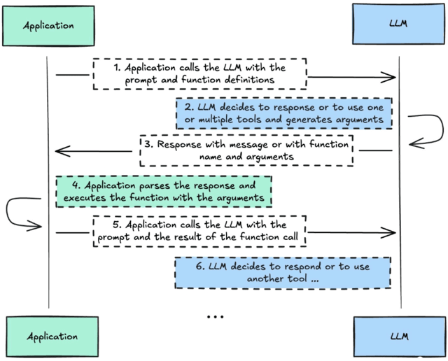

Since the LLM does not execute code directly, every calculation or data access goes through a sandbox that **you** control. You decide which functions are exposed and which arguments are valid – an important safety feature when handling sensitive policy or claims data.

## 4.2 Use Case: Mortality Data Retrieval from Database via Function Calling

In this use case, we show how Function Calling lets an LLM delegate deterministic data retrieval – here, fetching mortality probabilities for men aged 85–100 from an SQLite database – to a Python helper function, then focus on analysis and explanation. This ensures that data access is exact and auditable, while the model handles orchestration and narrative.

**Step 1: Application → LLM**  
*First, define our `fetch_probabilities` function, describe the function as well as its input parameters, register the function in the `tools` for the LLM, build the user prompt, and send both to the model.*

```python
# Define the function to fetch mortality probabilities
def fetch_probabilities(
    mortality_table: str,
    start_age: int,
    end_age: int,
    sex: str = "FEMALE"
):
    """
    Query the 'mortality_tables.sqlite' DB for all records in [start_age..end_age]
    matching the given table name and sex (default FEMALE). Returns, for example:
      [{ "age": 85, "probability": 0.123 }, ...]
    """
    # Normalize inputs
    sex = sex.upper()
    table = mortality_table.replace("'", "''")  # basic escape

    # Build SQL query
    sql = f"""
        SELECT age, probability
          FROM mortality_table
         WHERE mortality_table = '{table}'
           AND gender = '{sex}'
           AND age BETWEEN {start_age} AND {end_age}
         ORDER BY age
    """

    # Run SQL query
    conn = sqlite3.connect("mortality_tables.sqlite")
    cur = conn.cursor()
    cur.execute(sql)
    rows = cur.fetchall()
    conn.close()

    return [{"age": age, "probability": prob} for age, prob in rows]


# Register the function `fetch_probabilities` as a callable tool incl. descriptions
tools = [
    {
        "type": "function",
        "name": "fetch_probabilities",
        "description": "Fetch mortality probabilities from an SQLite database",
        "parameters": {
            "type": "object",
            "properties": {
                "mortality_table": {
                    "type": "string",
                    "description": "Name of the mortality table (e.g. 'PKV-Sterbetafel 2025')"
                },
                "start_age": {
                    "type": "integer",
                    "description": "Start age (inclusive)"
                },
                "end_age": {
                    "type": "integer",
                    "description": "End age (inclusive)"
                },
                "sex": {
                    "type": "string",
                    "enum": ["MALE", "FEMALE"],
                    "description": "Gender to filter by (defaults to FEMALE)",
                    "default": "FEMALE"
                }
            },
            "required": ["mortality_table", "start_age", "end_age"]
        }
    }
]

# Compose user request
user_prompt = (
    'Please fetch the probabilities for men between age 85 and one hundred from the mortality table '
    '"PKV-Sterbetafel 2025". First, present the data in a markdown-formatted table with columns '
    '"Age" and "Probability". Then, analyze the progression of these probabilities: indicate whether '
    'they increase monotonically, highlight any deviations, and summarize the overall trend.'
)
input_messages = [{"role": "user", "content": user_prompt}]

# Send prompt + function definition to the model
response = client.responses.create(
    model=MODEL_DEFAULT,
    input=input_messages,
    tools=tools
)
```

**Step 2: LLM reasoning**  
*The model decides internally whether to call `fetch_probabilities` or reply directly. We can check its decision type.*

```python
# 2) Inspect the first chunk of the response
first_chunk = response.output[0]
if hasattr(first_chunk, "name"):
    print(f"Model decided to call function: {first_chunk.name}")
else:
    print("Model returned a direct message.")
```

```
Model decided to call function: fetch_probabilities
```

**Step 3: LLM → Application**  
*The model returns a `function_call` message with the function name and JSON arguments.*

```python
# Extract the function call details
tool_call = response.output[0]         # contains name, call_id, arguments
args = json.loads(tool_call.arguments) # parse the JSON arguments
print("Invoking:", tool_call.name, "with", args)
```

```
Invoking: fetch_probabilities with {'mortality_table': 'PKV-Sterbetafel 2025', 'start_age': 85, 'end_age': 100, 'sex': 'MALE'}
```

**Step 4: Application Layer**  
*Execute the helper function with the generated arguments to fetch the data.*

```python
# Run the Python function to get mortality probabilities
fn_result = fetch_probabilities(**args)
```

**Step 5: Application → LLM**  
*Append the function call and its output to the conversation, then re-invoke the model so it can integrate the results.*

```python
# Provide the function output back to the LLM for context
input_messages.append(tool_call)
input_messages.append({
    "type": "function_call_output",
    "call_id": tool_call.call_id,
    "output": json.dumps(fn_result)
})

# Second API call to generate the final write-up
response_2 = client.responses.create(
    model=MODEL_DEFAULT,
    input=input_messages,
    tools=tools
)
```

**Step 6: LLM reasoning and (possibly) final response**  
*Finally, the LLM uses the fetched probabilities to produce a markdown table and analysis.*

```python
# Print GPT's markdown-formatted table + trend analysis
print(response_2.output_text)
```

```
Here is the data presented in a markdown-formatted table:

| Age | Probability |
|-----|-------------|
| 85  | 0.06308     |
| 86  | 0.07318     |
| 87  | 0.084803    |
| 88  | 0.098028    |
| 89  | 0.112913    |
| 90  | 0.129465    |
| 91  | 0.147647    |
| 92  | 0.167363    |
| 93  | 0.188107    |
| 94  | 0.209873    |
| 95  | 0.232032    |
| 96  | 0.24325     |
| 97  | 0.25129     |
| 98  | 0.25896     |
| 99  | 0.26621     |
| 100 | 0.27302     |

Analysis of the progression of probabilities:

- The probabilities increase overall with age from 85 to 100.
- The increase is monotonic; there are no decreases or deviations where the probability goes down.
- The values start at 0.06308 at age 85 and steadily rise to 0.27302 by age 100.
- This indicates a consistent increase in mortality probability with advancing age in this range.

Summary:
The mortality probabilities for men aged 85 to 100 in the "PKV-Sterbetafel 2025" table increase monotonically without any deviations, showing a clear trend of increasing mortality risk with higher age.
```

## 4.3 Further Applications and Resources

#### Additional Actuarial Applications for Function Calling

- **Dynamic Tariff Calculation** – Business users adjust inputs such as coverage limits, deductibles, and risk loadings in chat; the LLM invokes a tariff-calculation function to instantly recalculate quotes, making it easy for non-technical staff to explore “what-if” scenarios.
- **Customer Service with Live Data** – Policyholders ask about their renewal dates, payment history, or coverage details; the model triggers API calls to retrieve up-to-date information and presents it in a clear, conversational format.
- **Risk Scenario Simulation** – Risk managers describe stress-test parameters in natural language; the LLM calls a simulation engine function to run Monte Carlo scenarios and returns summarized KPIs and distribution charts.
- **Automated Policy Issuance** – A non-technical underwriter describes client details in plain language; the model calls a policy-generation function that computes premiums, applies endorsements, and returns a ready-to-issue document without any manual coding.

#### Further Reading and Resources on Function Calling

1. [Function Calling – OpenAI API Guide](https://platform.openai.com/docs/guides/function-calling)
   - *Type:* Official Documentation
   - *Summary:* Explains the `tools` and `tool_choice` parameters, JSON schema definition for arguments, parallel calls, and best‑practice safeguards—foundational for letting an actuarial chatbot trigger premium calculations or database look‑ups.
2. [How to Call Functions with Chat Models – OpenAI Cookbook](https://cookbook.openai.com/examples/how_to_call_functions_with_chat_models)
   - *Type:* Cookbook Notebook
   - *Summary:* Step‑by‑step Python notebook creating a weather‑bot, illustrating clarification questions, forced vs. automatic calls, and execution loop—easy template for actuaries to call Python pricing libraries from GPT‑4o.
3. [OpenAI Function Calling Tutorial: Generate Structured Output](https://www.datacamp.com/tutorial/open-ai-function-calling-tutorial)
   - *Type:* Tutorial / Blog Post
   - *Summary:* Hands‑on guide (Dec 2024) that contrasts “plain prompts” vs. function‑calling, then builds a Python script returning nested JSON—ideal for extracting policy attributes or claim details consistently.
4. [Fine-Tuning for Function Calling – OpenAI Cookbook](https://cookbook.openai.com/examples/fine_tuning_for_function_calling)
   - *Type:* Cookbook Notebook
   - *Summary:* Demonstrates how to fine-tune a chat model to improve function-calling accuracy and reliability. Covers assessing baseline performance, generating synthetic prompt-call pairs with GPT-4o, and running fine-tuning jobs—key for complex actuarial toolsets where multiple functions and parameters must be disambiguated.
5. [How to Use Function Calling with Azure OpenAI Service](https://learn.microsoft.com/en-us/azure/ai-services/openai/how-to/function-calling)
   - *Type:* Vendor Guide
   - *Summary:* Azure‑specific tutorial (Apr 2025) shows single‑ and parallel‑function scenarios, highlights the move from `functions`→`tools`, and includes full Python code—ready to integrate with actuarial data stores in Azure.

# 5. Fine‑Tuning

## 5.1 Concept and Purpose

Fine-tuning adapts a (pre-trained) LLM to your specific domain by continuing training on a curated set of labelled examples. Unlike prompt engineering – where you provide context and examples at inference time – fine-tuning adjusts the model's internal weights, yielding permanent improvements that no longer require repeated context. In this section, we focus on the standard supervised fine-tuning workflow; alternative approaches such as Direct Preference Optimization (DPO) and reinforcement-based methods also exist but are beyond our scope.

By fine-tuning, you effectively teach the model your "language" – whether that's your company's tone, structure and content of reports, complex insurance rules, or the precise interpretation of structured claim data. The result is a model that delivers more relevant, reliable, and efficient outputs in your actuarial context.

#### Why It Matters to Actuaries

- **Regulatory precision** – Fine-tuned models can reproduce mandatory wording (e.g., Solvency II or IFRS 17 disclosures) verbatim, minimizing compliance risks and hallucinations.
- **Data privacy and efficiency** – Proprietary inputs such as loss triangles or tariff tables are used only during training; inference no longer requires repeated exposure of sensitive data.
- **Consistent decision-making** – Underwriting assessments or claims triage follow the same trained logic every time, reducing reviewer variability.
- **Lower cost and latency** – Tailored, fine-tuned models often match the accuracy of much larger general-purpose models, resulting in faster responses and reduced compute costs – critical for production environments.

**Note**

Model distillation is a form of fine-tuning in which a compact "student" model is trained on the soft-label outputs of a larger "teacher" model. By learning to reproduce the teacher's probability distributions, the student retains most of the teacher's domain knowledge while operating with significantly lower latency and resource demands.

#### A Three-Step Fine-Tuning Workflow

**Step 1: Data Preparation**  
Collect representative prompt–response pairs that reflect your actuarial use case, and format them as required by your LLM provider (e.g., JSONL for OpenAI). Ensure balanced coverage across all relevant categories, then split the dataset into training and validation subsets.  
*Tip: OpenAI recommends at least 50 high-quality examples per task (the absolute minimum is 10); see the [OpenAI Fine-Tuning guide](https://platform.openai.com/docs/guides/fine-tuning) for details.*

**Step 2: Training**  
Upload your dataset to your chosen platform (e.g., OpenAI's fine-tuning endpoint) and launch a fine-tuning job. Optionally, configure hyperparameters – such as learning rate, batch size, and number of epochs – to suit your training objectives.

**Step 3: Deployment & Governance**  
After fine-tuning completes, the new model obtaines a unique identifier. Use this ID in your API calls to invoke the fine-tuned model.

The duration of a fine-tuning job varies with the volume of training data – it may finish in minutes or take several hours. Upon successful completion, you'll receive an email alert at your registered address. Below is a sample notification message.

[figure not shown]

*Notification from OpenAI confirming that the fine-tuning job completed successfully and displaying the fine-tuned model’s identifier.*  
*[Source: Email from OpenAI.]*

## 5.2 Use Case: Improving Car Damage Classification by Fine-Tuning Vision-Enabled LLMs

In this case study, we use a dataset on car damages sourced from a [Kaggle competition hosted by Analytics Vidhya](https://www.kaggle.com/datasets/imnandini/analytics-vidya-ripik-ai-hackfest), a platform dedicated to data science education and challenges. The dataset contains thousands of car images, each labeled with one of six damage categories: crack, scratch, tire flat, dent, glass shatter, or lamp broken. Our objective is to demonstrate that a fine-tuned LLM-based classifier delivers higher accuracy in damage categorization than its non-fine-tuned counterpart.

The following code snippet uses the `kagglehub` library to download the latest version of the dataset directly from Kaggle. Note that for the respective code to work properly, you must have a Kaggle account and configure your Kaggle environment (for example, by placing your Kaggle API credentials in the appropriate location) to access and import the dataset directly. Alternatively, you can also download the dataset from the source above.

```python
# Download latest version from Kaggle
path = kagglehub.dataset_download("imnandini/analytics-vidya-ripik-ai-hackfest")
```

In the code below, we load the dataset and define a label map to translate numeric class IDs into human-readable damage categories. We then display the first eight records to give a quick overview of the dataset's structure and contents.

```python
# Create a mapping for the labels
label_mapping = {
    1: "crack",
    2: "scratch",
    3: "tire flat",
    4: "dent",
    5: "glass shatter",
    6: "lamp broken"
}

# Load dataset
df = pd.read_csv(os.path.join(path, "train/train/train.csv"))

# Rename label column to label_id for clarity and adjust to start from 0
df.rename(columns={'label': 'label_id'}, inplace=True)

# Add label_text column using the mapped values
df['label_text'] = df['label_id'].map(label_mapping)

# Display the first 8 rows of the updated dataframe
df.head(8)
```

|  | image_id | filename | label_id | label_text |
| --- | --- | --- | --- | --- |
| 0 | 1 | 1.jpg | 2 | scratch |
| 1 | 2 | 2.jpg | 4 | dent |
| 2 | 3 | 3.jpg | 2 | scratch |
| 3 | 4 | 4.jpg | 3 | tire flat |
| 4 | 5 | 5.jpg | 5 | glass shatter |
| 5 | 6 | 6.jpg | 2 | scratch |
| 6 | 7 | 7.jpg | 5 | glass shatter |
| 7 | 8 | 8.jpg | 5 | glass shatter |

The dataset consists not only of the tabular metadata shown above but also of the corresponding JPEG images. The following code combines the first eight images with their associated metadata to provide a visual impression of the damage types alongside their descriptive information.

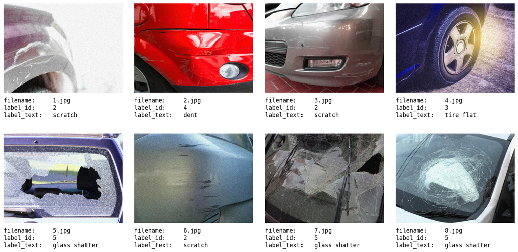

```python
# Define the folder path for the images corresponding to the filenames of df
image_folder = os.path.join(path, "train/train/images/")

# Prepare to display the first 8 images in a 2x5 grid
num_images = 8
num_cols = 4
num_rows = 2
fig, axs = plt.subplots(num_rows, num_cols, figsize=(15, 8))

# Iterate through the first 8 images
for idx in range(num_images):
    # Calculate the row and column indices for the current subplot
    row = idx // num_cols
    col = idx % num_cols

    # Get metadata for the current image
    filename = df.loc[idx, 'filename']
    label_id = df.loc[idx, 'label_id']
    label_text = df.loc[idx, 'label_text']

    # Open image and display it
    with Image.open(os.path.join(image_folder, filename)) as img:
        axs[row, col].imshow(img)
        axs[row, col].axis('off')

    # Add all metadata as left-aligned text below the image
    axs[row, col].text(
        0, -0.05,
        f"filename:     {filename}\n"
        f"label_id:     {label_id}\n"
        f"label_text:   {label_text}",
        fontsize=12,
        va='top',
        ha='left',
        transform=axs[row, col].transAxes,  # Use axis-relative coordinates
        wrap=True,
        fontfamily='monospace'
    )

# Adjust layout to prevent overlap
plt.tight_layout()
plt.show()
```

```python
# Sample 1500 entries from the original dataframe
df_sampled = df.sample(1500, random_state=123).reset_index(drop=True)

# Split the data into train (60%), validation (20%), and test (20%) sets
df_train, df_test = train_test_split(df_sampled, test_size=0.2, stratify=df_sampled['label_id'], random_state=123)
df_train, df_val = train_test_split(df_train, test_size=0.25, stratify=df_train['label_id'], random_state=123)
```

To systematically store and later evaluate the model predictions alongside the actual labels, we first initialize a data structure that holds the ground-truth labels from the test dataset. Predictions from the non-fine-tuned model and the fine-tuned model will be added in the following subsections.

```python
# Initialize a results DataFrame with actual labels from the test set
results_df = pd.DataFrame({
    "filename": df_test["filename"],
    "actual_label_id": df_test["label_id"]
    # Predictions from different models will be added later
})
```

#### Non-Fine-Tuned LLM

First, we explore the use of a non-fine-tuned Large Language Model for the damage classification task. Specifically, we employ an off-the-shelf version of GPT-4o, a multimodal model inherently equipped with vision capabilities, to predict the type of car damage directly from the image data.

To enable GPT-4o to process the images, we first encode them into a Base64 string representation, effectively converting the binary image data into a text format suitable for model input.

```python
# Function to encode the image
def encode_image(image_path):
    with open(image_path, "rb") as image_file:
        return base64.b64encode(image_file.read()).decode("utf-8")
```

Before making predictions with GPT-4o, we define a system prompt for the `instructions` parameter that will be provided during each model call. This prompt clearly instructs the LLM to classify the damage type visible in the image into exactly one of the six predefined categories. It emphasizes strict adherence to the specified output format to ensure consistency and accuracy across all predictions.

```python
SYSTEM_PROMPT = """
You will classify images of cars with visible damages into one of six specific classes. Your task is to examine the image provided, identify the type of damage, and return the correct damage type as one of the predefined classes. The six damage classes are as follows:

1. crack
2. scratch
3. tire flat
4. dent
5. glass shatter
6. lamp broken

# Steps

1. **Analyze the Image:**
   - Carefully inspect the image provided, focusing on visible damage to determine its type.
   - Pay attention to details such as patterns, locations, and characteristics of the damage to accurately classify it.

2. **Identify the Correct Class:**
   - Match the observed damage to one of the six predefined classes listed above.
   - Avoid ambiguous classifications and ensure the answer aligns precisely with the provided options.

3. **Output the Classification:**
   - Provide your answer in a concise format with **only the name of the damage class** (e.g., "scratch").
   - Do not add any additional text, reasoning, or explanations. The response must be exactly one of the six class names.

# Notes
- If multiple damage types appear equally prominent in the image, select the one that seems most severe or predominant.
- Ensure every response falls strictly within the six defined classes. Avoid assumptions or interpretations beyond the scope of these categories.

# Example Format
For an input image with a visible scratch:
- Correct Output: "scratch"

For an input image showing a shattered glass window:
- Correct Output: "glass shatter"

Adhere to this strict output format and guidelines in every classification.
"""
```

Although the LLM is instructed to return exaclty one of the six specified damage types, variations in the output (e.g., different quotation styles such as `scratch`, `'scratch'`, or `"scratch"`) may occur. To enforce a consistent and strict output format, we employ, again, the concept of Structured Outputs introduced in Section 3. The code below defines a response schema using a Pydantic model that restricts the prediction to one of the six damage classes.

```python
# Define the response format for the OpenAI model using Structured Outputs
class ResponseFormat(BaseModel):
    prediction: Literal["crack", "scratch", "tire flat", "dent", "glass shatter", "lamp broken"]
```

In the following function, we query an LLM with vision capabilities by providing the base64-encoded textual representation of an image, along with the previously defined system prompt and Structured Outputs (via the `text_format` parameter), to predict the corresponding damage type.

```python
# Helper function to get prediction from an OpenAI model
def get_llm_image_prediction(encoded_image, model_name, system_prompt):
    """
    Queries an LLM with vision capabilities to predict a label from an encoded image.
    """
    try:
        response = client.beta.chat.completions.parse(
            model=model_name,
            messages=[
                {"role": "system", "content": [{"type": "text", "text": system_prompt}]},
                {"role": "user", "content": [{"type": "image_url",
                                              "image_url": {"url": f"data:…",
                                                            "detail": "low"}}]}
            ],
            response_format=ResponseFormat
        )
        return response.choices[0].message.parsed.prediction
    except Exception as e:
        print(f"Error getting prediction from model '{model_name}': {e}")
        return None
```

Below, we obtain predictions for each test image using the non-fine-tuned, off-the-shelf GPT-4o. Each image is encoded in Base64, the LLM's textual output is then mapped back to its corresponding label ID via a reverse mapping, and the resulting predictions are stored in our results DataFrame for later evaluation.

```python
# Set model name of the non-fine-tuned LLM
non_fine_tuned_llm_model = "gpt-4o-2024-08-06"

# Create a reverse mapping from label text to label ID
label_text_to_id = {v: k for k, v in label_mapping.items()}

# Obtain non-fine-tuned LLM predictions for each test image
non_fine_tuned_predictions = []
for _, row in df_test.iterrows():
    image_path = os.path.join(image_folder, row['filename'])
    encoded_image = encode_image(image_path)

    # Retrieve the non-fine-tuned LLM's prediction (as label text)
    pred_label_text = get_llm_image_prediction(encoded_image, non_fine_tuned_llm_model, SYSTEM_PROMPT)

    # Map the predicted label text back to its corresponding label ID
    pred_label_id = label_text_to_id.get(pred_label_text, None)
    non_fine_tuned_predictions.append(pred_label_id)

# Store the non-fine-tuned LLM predictions in the results DataFrame
results_df["non_fine_tuned_llm_predicted_label_id"] = non_fine_tuned_predictions
```

#### Fine-Tuned LLM

To fine-tune our vision-enabled GPT-4o model on domain-specific data, we must first prepare the dataset in the JSONL format required for OpenAI's fine-tuning. Each training example is structured as a series of messages—including a system prompt that corresponds to the previously defined instructions and defines the task, a user message containing the base64-encoded image, and (optionally) an assistant message with the ground truth label—to ensure consistent and reliable outputs according to OpenAI's Structured Outputs framework. The following function generates a JSONL file from our dataset:

```python
def create_jsonl(input_df, img_folder_path, output_file, include_assistant=True):
    """
    Generates a JSONL file from the input DataFrame.

    Parameters:
    - input_df: DataFrame containing the input data.
    - img_folder_path: Path to the folder containing the images.
    - output_file: Output JSONL file path.
    - include_assistant: Boolean to determine if the assistant message is included.
    """
    json_data = []

    for idx, row in tqdm(input_df.iterrows(), total=len(input_df)):
        # Encode the image in base64 format
        image_path = os.path.join(img_folder_path, row['filename'])
        encoded_image = encode_image(image_path)

        # System message
        system_message = {
            "role": "system",
            "content": [{"type": "text", "text": SYSTEM_PROMPT}]
        }

        # User message (image input)
        user_message = {
            "role": "user",
            "content": [
                {"type": "image_url", "image_url": {"url": f"data:…", "detail": "low"}}
            ]
        }

        # Combine system and user messages
        all_messages = [system_message, user_message]

        # Add assistant message if specified
        if include_assistant:
            assistant_message = {
                "role": "assistant",
                "content": [{"type": "text", "text": row["label_text"]}]
            }
            all_messages.append(assistant_message)

        # Add to JSON data
        json_data.append({"messages": all_messages})

    # Save to JSONL file
    with open(output_file, "w") as file:
        for entry in json_data:
            file.write(json.dumps(entry) + "\n")
```

Next, we generate JSONL files for each data split—training, validation, and test. The training and validation files include the assistant messages (i.e., the correct labels), whereas the test file is generated without them, as it will be used solely for evaluation during fine-tuning.

```python
# Create JSONL for the training dataset
create_jsonl(
    input_df=df_train,
    img_folder_path=image_folder,
    output_file="visual_fine_tuning_train.jsonl",
    include_assistant=True
)

# Create JSONL for the validation dataset
create_jsonl(
    input_df=df_val,
    img_folder_path=image_folder,
    output_file="visual_fine_tuning_validation.jsonl",
    include_assistant=True
)

# Create JSONL for the test dataset without assistant messages
create_jsonl(
    input_df=df_test,
    img_folder_path=image_folder,
    output_file="visual_fine_tuning_test.jsonl",
    include_assistant=False
)
```

Finally, if we choose to proceed with fine-tuning, we upload the training and validation JSONL files to the OpenAI platform and initiate a fine-tuning job using the vision-enabled GPT-4o model. The code snippet below demonstrates how to upload these files and create the fine-tuning job, controlled by the flag `create_fine_tuning_job`.

```python
create_fine_tuning_job = False
if create_fine_tuning_job:
    # upload training file
    train_file = client.files.create(
        file=open("visual_fine_tuning_train.jsonl", "rb"),
        purpose="fine-tune"
    )

    # upload validation file
    val_file = client.files.create(
        file=open("visual_fine_tuning_validation.jsonl", "rb"),
        purpose="fine-tune"
    )

    # create fine tuning job
    client.fine_tuning.jobs.create(
        training_file=train_file.id,
        validation_file=val_file.id,
        model="gpt-4o-2024-08-06"
    )
```

To conclude, we obtain predictions for each test image using our fine-tuned vision-enabled LLM. In this step, each image is encoded to Base64 and fed to the model via the same prediction function used for the non-fine-tuned LLM, after which the output text is mapped back to its corresponding label ID and stored in the results DataFrame.

```python
# Set model name of the fine-tuned LLM
fine_tuned_llm_model = "ft:gpt-4o-2024-08-06:personal::B5swMoBf"

# Obtain fine-tuned LLM predictions for each test image
fine_tuned_predictions = []
for _, row in df_test.iterrows():
    image_path = os.path.join(image_folder, row['filename'])
    encoded_image = encode_image(image_path)

    # Retrieve the fine-tuned LLM's prediction (as label text)
    pred_label_text = get_llm_image_prediction(encoded_image, fine_tuned_llm_model, SYSTEM_PROMPT)

    # Map the predicted label text back to its corresponding label ID
    pred_label_id = label_text_to_id.get(pred_label_text, None)
    fine_tuned_predictions.append(pred_label_id)

# Store the fine-tuned LLM predictions in the results DataFrame
results_df["fine_tuned_llm_predicted_label_id"] = fine_tuned_predictions
```

Finally, we quantitatively assess our models by computing accuracy on the test set, which measures the proportion of correctly classified images. Accuracy is only one performance metric; one could also evaluate (weighted) F1 scores, inspect confusion matrices, or review cases where the two models disagree to gain deeper insights.

```python
# Extract labels
actual_labels = results_df["actual_label_id"]
non_fine_tuned_labels = results_df["non_fine_tuned_llm_predicted_label_id"]
fine_tuned_labels = results_df["fine_tuned_llm_predicted_label_id"]

# Compute accuracy and weighted F1-score, rounded to three decimal places
metrics = {
    "Model": ["Non-Fine-Tuned LLM", "Fine-Tuned LLM"],
    "Accuracy": [
        round(accuracy_score(actual_labels, non_fine_tuned_labels), 3),
        round(accuracy_score(actual_labels, fine_tuned_labels), 3)
    ]
}

# Create DataFrame
metrics_df = pd.DataFrame(metrics)
metrics_df
```

|  | Model | Accuracy |
| --- | --- | --- |
| 0 | Non-Fine-Tuned LLM | 0.86 |
| 1 | Fine-Tuned LLM | 0.89 |

## 5.3 Further Applications and Resources

#### Additional Actuarial Applications for Fine-Tuning

- **Consistent and Efficient Report Generation** – Fine-tuned models leverage historical documents and associated numerical data—from actuarial reserves and risk assessments to technical documentation and sustainability reports—to reliably produce new reports or specific report sections. Users simply input updated figures, and the model automatically generates consistent, compliant, and professionally styled outputs, significantly streamlining reporting workflows.
- **Customer Service Automation** – Chatbots trained on policy documentation and FAQs accurately handle customer inquiries on coverage and premiums, providing consistent responses in the company's style and voice.
- **Fraud Detection & Claims Triage** – Models fine-tuned on historical fraud cases rapidly flag suspicious claims or route complex cases to specialists, improving efficiency and accuracy of fraud detection.
- **Automated Claims Assessment** – Fine-tuned models quickly categorize claims based on damage descriptions, photos, and adjuster notes, streamlining settlements and significantly reducing processing times.

#### Further Reading and Resources on Fine-Tuning

1. [Fine‑Tuning Now Available for GPT‑4o](https://openai.com/index/gpt-4o-fine-tuning/)
   - *Type:* Official Blog Announcement
   - *Summary:* Details Aug 2024 launch of GPT‑4o fine‑tuning, token pricing, and early results showing strong gains from a few dozen domain‑specific examples—helpful when you need the model to use actuarial jargon or calculation styles.
2. [How to Fine‑Tune Chat Models – OpenAI Cookbook](https://cookbook.openai.com/examples/how_to_finetune_chat_models)
   - *Type:* Cookbook Notebook
   - *Summary:* Full Python workflow (Jul 2024) covering dataset prep, upload, job creation, and evaluation; includes a cost estimator and token‑count utility—pragmatic template for building a custom reserving‑assistant model.
3. [Fine-Tuned Classification – OpenAI Cookbook](https://cookbook.openai.com/examples/fine_tuned_classification)
   - *Type:* Cookbook Notebook
   - *Summary:* Detailed tutorial (updated Mar 2025) demonstrating fine-tuning a `babbage-002` model for classification tasks. It covers data formatting, JSONL dataset uploading, initiating fine-tuning jobs, and post-training evaluation—an excellent resource for actuaries classifying claims as fraudulent or legitimate, or assigning underwriting risk categories.
4. [Fine‑Tuning – OpenAI API Documentation](https://platform.openai.com/docs/guides/fine-tuning)
   - *Type:* Official Documentation
   - *Summary:* Authoritative reference on data format, required example count, validation splits, and CLI vs. API job control—key for governance/compliance sign‑off on actuarial fine‑tunes.
5. [Azure OpenAI GPT‑4o‑mini Fine‑Tuning Tutorial](https://learn.microsoft.com/en-us/azure/ai-services/openai/tutorials/fine-tune)
   - *Type:* Vendor Tutorial
   - *Summary:* March 2025 walk‑through that fine‑tunes `gpt‑4o‑mini‑2024‑07‑18`, covers dataset creation, job monitoring, deployment, and cost caveats—perfect for insurers leveraging Azure for model hosting.
6. [Case Study: Car Damage Classification and Localization with Fine-Tuned Vision-Enabled LLMs](https://github.com/IAA-AITF/Actuarial-AI-Case-Studies/tree/main/case-studies/2025/car_damage_classification_and_localization)
   - *Type:* Case Study
   - *Summary:* Jupyter Notebook with more detailed information on how to use fine-tuned vision-enabled LLMs for car damage classfication and localization.

# 6. Retrieval‑Augmented Generation

## 6.1 Concept and Purpose

Retrieval-Augmented Generation (RAG) combines LLMs with external data sources to produce responses that are not only linguistically coherent but also factually grounded. The core principle behind RAG is that instead of relying entirely on knowledge embedded within the model, it selectively accesses external resources—such as databases, document repositories, or APIs—whenever specific and up-to-date information is required.

By integrating the natural-language strengths of LLMs with the precision of external data sources, RAG helps produce outputs that are:

- **Current**, as external information can be continuously updated and seamlessly incorporated.
- **Accurate**, by directly accessing relevant, authoritative data sources rather than relying on generalized knowledge.
- **Flexible**, because new data sources can be quickly added or existing sources easily updated, allowing dynamic adaptation to changing information needs.

The implementation of a typical RAG workflow consists of five main stages, as illustrated in Figure 5:

1. **Indexing (Chunking, Vectorize & Store)**
   - Source materials (e.g., actuarial reports, policies, or regulations) are segmented into smaller, manageable pieces ("chunks"). This enables precise, targeted retrieval.
   - Each chunk is transformed into a semantic vector, mathematically representing its meaning in a high-dimensional space. These vectors are stored in a specialized, optimized data structure (such as a vector database) that allows rapid and accurate retrieval.
2. **Vectorize & Search**
   - The user query is similarly transformed into a semantic vector, capturing its meaning and intent.
   - A search algorithm compares this query vector against the stored document vectors, identifying the most semantically similar chunks using an appropriate similarity metric, ensuring highly relevant retrieval results.
3. **Retrieve**
   - Based on the query-vector comparison, the system fetches the most relevant chunks or documents from the vector database. These retrieved documents contain information directly applicable to the user's query.
4. **Augment**
   - The original query, retrieved chunks, and any additional contextual instructions or system prompts are combined into an enriched prompt. This augmented prompt provides the LLM with both the user's question and the necessary external context for accurate answering.
5. **Generate**
   - The LLM processes the enriched prompt, synthesizing the retrieved external information with its inherent linguistic and contextual understanding, ultimately producing a coherent, informative, and contextually relevant response.

By following this structured approach, RAG enables actuaries to leverage the interpretative capabilities of LLMs alongside continuously updated domain-specific data, ensuring outputs remain precise, compliant, and fully aligned with current actuarial practice.

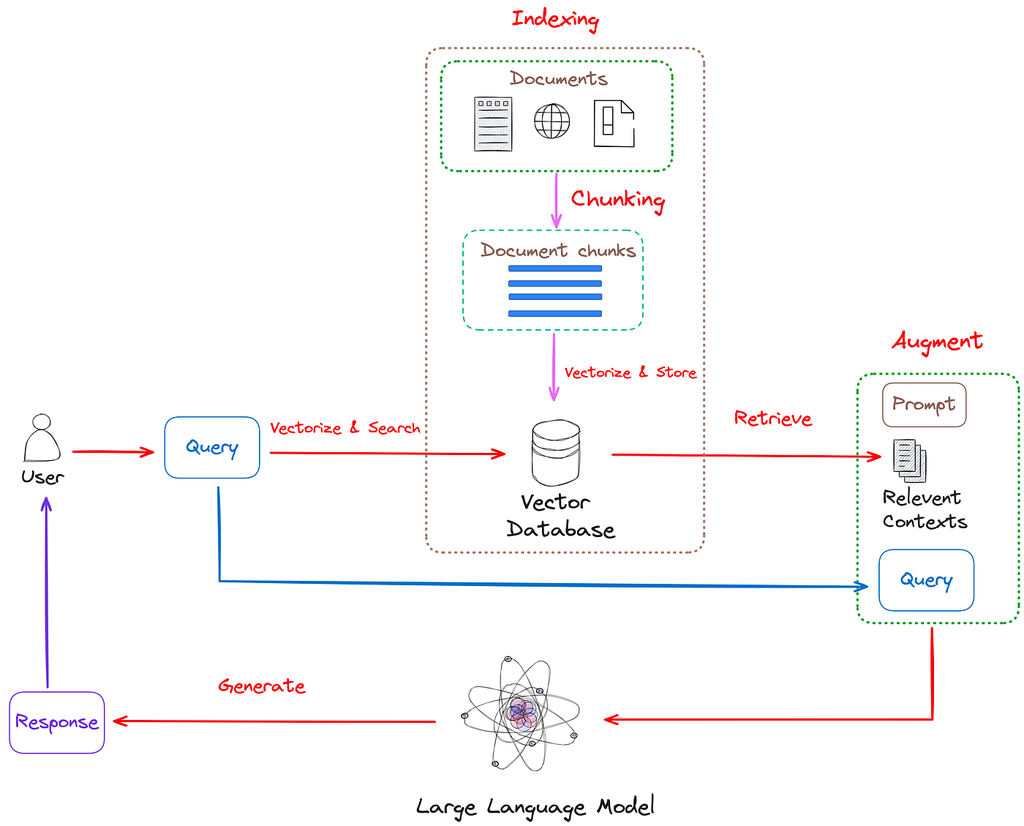

*Schematic illustration of the individual phases of RAG.*  
*[Source: https://ai.plainenglish.io/a-brief-introduction-to-retrieval-augmented-generation-rag-b7eb70982891]*

**Note**

RAG is an emerging field, yielding new approaches like **GraphRAG** from Microsoft, which extends RAG by also incorporating a knowledge graph representing semantic relations between relevant entities, or **AgenticRAG** approaches, where the query generation is improved by an underlying agent.

## 6.2 Use Case: Extracting KPIs from Annual Reports with RAG

Before we start, we define some constants that will be used in our RAG system.

```python
# Specify the large language model and embeddings model to be used
LARGE_LANGUAGE_MODEL = "gpt-4.1-mini"
EMBEDDINGS_MODEL = "text-embedding-3-small"

# Set parameters for text chunking and retrieval to manage context and similarity search
CHUNK_SIZE = 2000  # Size of text chunks in characters
OVERLAP = 300      # Overlap between text chunks for context coherence
TOP_N = 5          # Number of top similar chunks to retrieve
THRESHOLD = 0.5    # Threshold for cosine similarity to consider chunks as similar

# Link to Generali's Annual Report from 2024
GENERALI_ANNUAL_REPORT_LINK = "https://www.generali.com/doc/jcr:259c5d6e-46f7-4a43-9512-58e5dcbd2a56/Annual%20Integrated%20Report%20and%20Consolidated%20Financial%20Statements%202024_Generali%20Group_final_interactive.pdf/lang:en/Annual_Integrated_Report_and_Consolidated_Financial_Statements_2024_Generali_Group_final_interactive.pdf"
```

#### Stage 1: Preprocessing

```python
def load_pdf_from_url(url: str):
    """
    Fetches a PDF from the given URL into memory and returns its extracted text.

    :param url: Direct URL to the PDF.
    :return: A dict with 'filename' (derived from URL) and 'text' (full document text).
    """
    # 1. Fetch PDF bytes
    resp = requests.get(url)
    resp.raise_for_status()
    pdf_bytes = resp.content

    # 2. Derive a filename from the URL path
    path = urlparse(url).path
    filename = unquote(path.split("/")[-1])

    # 3. Open PDF from bytes and extract text
    doc = fitz.open(stream=pdf_bytes, filetype="pdf")
    full_text = []
    for page in doc:
        full_text.append(page.get_text())
    text = "\n".join(full_text)

    return {"filename": filename, "text": text}
```

Before proceeding with chunking and vectorization, we define a function to clean the input text. This function removes unnecessary characters, redundant spaces, and empty lines, ensuring that the text is properly formatted for the next steps in the process.

```python
def clean_text(text):
    """
    Cleans a text segment by removing unwanted characters and patterns.

    :param text: Input text segment.
    :return: Cleaned text segment.
    """
    # Remove extra spaces between words
    cleaned_text = re.sub(r'[ \t]+', ' ', text)
    # Remove leading and trailing spaces
    cleaned_text = cleaned_text.strip()
    # Remove empty lines
    cleaned_text = re.sub(r'\n\s*\n', '\n', cleaned_text)
    return cleaned_text
```

Next, we define a function to split the cleaned text into overlapping chunks. The chunking is done by breaking the text after a fixed number of characters, with an overlap between adjacent chunks. This ensures that each chunk contains enough context for retrieval tasks. An alternative approach could involve splitting by tokens or ensuring that chunks don't cut through sentences, but for simplicity, we use character-based chunking in this example.

```python
def create_chunks(text, chunk_size=CHUNK_SIZE, overlap=OVERLAP):
    """
    Splits text into overlapping chunks.

    :param text: Input text to be split into chunks.
    :param chunk_size: Target size of each chunk.
    :param overlap: Overlap between adjacent chunks.
    :return: List of text chunks.
    """
    if chunk_size <= overlap:
        raise ValueError("chunk_size must be greater than overlap.")
    return [
        text[i: i + chunk_size]
        for i in range(0, len(text), chunk_size - overlap)
    ]
```

To generate embeddings for the text, we use a pre-trained OpenAI embeddings model. The embeddings represent the semantic meaning of the text as a high-dimensional numerical vector, which can be used for similarity-based retrieval. While we use OpenAI's embeddings model in this example, readers are free to explore other models depending on their specific needs.

```python
def generate_text_embedding(chunk, model=EMBEDDINGS_MODEL):
    """
    Generates a numerical embedding for a given text chunk using a specified model.

    :param chunk: The text chunk for which the embedding is generated.
    :param model: The embedding model to be used (default is EMBEDDINGS_MODEL).
    :return: A list of float values representing the embedding of the input text chunk.
    """
    try:
        response = client.embeddings.create(
            model=model,
            input=chunk,
            encoding_format="float"
        )
        embedding = response.data[0].embedding
        return embedding
    except Exception as e:
        logging.error(f"Error generating embeddings for text: {e}")
        return None
```

Before generating embeddings, we first clean and chunk the document text using the previously defined functions. The text is cleansed to remove unwanted characters and then split into overlapping chunks. Finally, embeddings are generated for each chunk. This process prepares the text for similarity-based retrieval.

```python
def generate_document_embeddings(document, chunk_size=CHUNK_SIZE, overlap=OVERLAP):
    """
    Processes a list of documents by cleansing their content, creating chunks,
    and generating embeddings for each chunk.

    :param docs: List of documents containing 'filename' and 'text'.
    :param chunk_size: Target size of each text chunk.
    :param overlap: Overlap between adjacent chunks.
    :return: List of dictionaries containing 'filename', 'content', and 'embedding' for each chunk.
    """
    embeddings_data = []

    # Clean the text
    cleaned_document = clean_text(document)

    # Create chunks
    chunks = create_chunks(cleaned_document, chunk_size, overlap)

    # Generate embeddings for each chunk
    for chunk in chunks:
        embedding = generate_text_embedding(chunk)
        if embedding is not None:
            embeddings_data.append({
                "content": chunk,
                "embedding": embedding
            })

    return embeddings_data
```

We create a dictionary to store the embeddings DataFrames for each insurance company. For each company, we load the corresponding documents, generate embeddings, and store the results in a DataFrame. Note that this step may take several minutes.

```python
# Dictionary to store embeddings DataFrames for each company
company_embeddings_dict = {}

# Load documents
document = load_pdf_from_url(GENERALI_ANNUAL_REPORT_LINK)

# Process documents and generate embeddings
document_embeddings = generate_document_embeddings(document["text"])

# Create a DataFrame for the current company's embeddings
company_name = "Generali"
company_embeddings_dict[company_name] = pd.DataFrame(document_embeddings)
```

To verify the correct processing of Stage 1, we display one random row from the Generali embeddings DataFrame. This allows us to check if the text chunking and embedding generation have been performed correctly for this company.

```python
# Display one random row for the company "Generali"
company_embeddings_dict.get(company_name).sample(1)
```

|  | content | embedding |
| --- | --- | --- |
| 529 | it are defined by the Group Legal entities following centrally defined Group rules \nthat vary on the basis of the product’s features and type of coverage:\n• in the case of Saving contracts, the cove… | [0.0073534846, 0.02643166, 0.07489371, 0.03278103, -0.038192425, 0.009632284, -0.012626589, -0.024291152, 0.036268372, -0.006764244, 0.0038511096, -0.047379773, -0.023377227, -0.018651275, 0.036965843… |

#### Stage 2: Prompt Augmenting

While the first stage is largely independent of the specific information we aim to extract and needs to be conducted only once, Stage 2 focuses on identifying the relevant context within the input documents for each of the three key aspects (regulatory capital ratios under Solvency II or SST, discount rates for insurance contract valuations by year and currency, and strategies for assessing and mitigating cyber risk).

We start by defining a system prompt that provides context for the AI assistant. This prompt is used for each query to ensure consistent extraction of structured information from the documents.

```python
# Define an enhanced system prompt for consistent and accurate data extraction
system_prompt = '''
You are an AI assistant specialized in extracting and structuring key financial and risk insights from annual reports of European insurance companies. Use Retrieval-Augmented Generation to retrieve precise text segments and apply Structured Outputs to format data consistently. Identify and extract regulatory ratios, discount rates, and cyber risk strategies with exact numerical formats and contextual clarity. Ensure all outputs follow the specified schema for seamless integration into actuarial workflows and to support robust comparative analysis.
'''
```

To ensure relevant retrieval, we define detailed queries that guide the similarity search. Each query specifies the required data, attributes, and format, ensuring the extracted information is focused on the three key aspects solvency ratios, discount rates, and cybersecurity risk strategies.

```python
# Define queries for retrieving structured financial insights

# Query for extracting regulatory compliance ratios specifically for the year 2023
query_solvency_ratio = '''
Extract the group's solvency capital ratio in percentage for 2024, along with the regulatory framework (Solvency II or SST).
'''

# Query for retrieving discount rate data specifically for the year 2024
query_discount_rates = '''
Extract the discount rates for financial or insurance contract liabilities in 2024, using only currency EUR. For each duration (e.g., 1 year, 5 years, 10 years, 20 years, 40 years, etc.), extract the corresponding discount rate in percentage. Ensure that the data reflects the rates as of December 31, 2024. If no specific approach is mentioned, assume non-VFA, unit-linked contracts, or liquid products.
'''

# Query for identifying cybersecurity risk management strategies
query_cyber_risk_strategies = '''
Extract the insurer's documented approach to cyber-risk assessment and mitigation. Return each policy, process, or control as a separate text bullet, and include any references to governance bodies, frequency of reviews, or related quantitative metrics if available.
'''

# Store all queries in a list for easy access
queries = [query_solvency_ratio, query_discount_rates, query_cyber_risk_strategies]
```

Once we have our document embeddings and search query, this function performs vector-based similarity search to identify the most relevant text chunks. It generates an embedding for the query, calculates cosine similarity with document chunks, and ranks the results based on their similarity scores. The top matching snippets are then formatted into a structured output, ensuring that only the most relevant content is returned, ready to be used in an augmented prompt for the AI model.

```python
def retrieve_top_matching_chunks(document_embeddings, search_query, max_results=TOP_N, similarity_cutoff=THRESHOLD):
    """
    Identifies and formats the most relevant document chunks based on semantic similarity to a query.

    :param document_embeddings: List of document chunk embeddings.
    :param search_query: The query used to find relevant content.
    :param max_results: Maximum number of top matching results to return.
    :param similarity_cutoff: Minimum similarity score required for inclusion.
    :return: A formatted string containing the most relevant text snippets.
    """
    try:
        # Generate embedding for the query
        query_embedding = generate_text_embedding(search_query)
        if query_embedding is None:
            logging.error("Failed to generate query embedding.")
            return "No relevant content found."

        # Reshape query embedding for similarity calculation
        query_vector = np.array(query_embedding).reshape(1, -1)

        # Compute cosine similarity for each document embedding
        def compute_similarity(doc_vector):
            doc_vector_reshaped = np.array(doc_vector).reshape(1, -1)
            return cosine_similarity(query_vector, doc_vector_reshaped)[0][0]

        # Convert document embeddings into a DataFrame and compute similarity scores
        df_embeddings = pd.DataFrame(document_embeddings)
        df_embeddings['similarity'] = df_embeddings['embedding'].apply(compute_similarity)

        # Filter relevant results based on similarity threshold
        filtered_results = df_embeddings[df_embeddings['similarity'] > similarity_cutoff]

        if filtered_results.empty:
            logging.warning("No relevant content found.")
            return "No relevant content found."

        # Select top matching results
        top_matches = filtered_results.nlargest(max_results, 'similarity')

        # Format the retrieved snippets for AI model input
        formatted_snippets = "\n\n".join(
            f"Relevant Snippet {i+1}: {row['content']}"
            for i, (_, row) in enumerate(top_matches.iterrows())
        )

        return formatted_snippets

    except Exception as e:
        logging.error(f"Error in retrieving relevant text chunks: {e}")
        return "No relevant content found."
```

To retrieve relevant information for each company based on the predefined queries, we iterate over the list of companies and use their corresponding pre-calculated embeddings. For each query, we identify and store the most relevant text chunks from the company's document corpus. This process ensures that each company’s data is enriched with contextually relevant insights, making it ready for further analysis or model input.

```python
# Dictionary to store retrieved data for each company and each query
company_retrieved_data = {}

# Retrieve the pre-calculated embeddings for the current company
company_embeddings = company_embeddings_dict.get(company_name)

if company_embeddings is not None:
    # Initialize a dictionary to store the results for the current company
    company_retrieved_data[company_name] = {}

    # Iterate over each query and retrieve relevant information for the company
    for query_text in queries:
        # Retrieve the relevant text chunks for the current query
        retrieved_information = retrieve_top_matching_chunks(company_embeddings, query_text)
        company_retrieved_data[company_name][query_text] = retrieved_information
else:
    # Log if no embeddings were found for the company
    logging.warning(f"No embeddings found for company '{company_name}'.")
```

To verify the correctness and relevance of the retrieved information, we can perform a check for a specific company and query. This step ensures that the data retrieval process is functioning as expected and provides an example of the most relevant context for a given company-query combination.

```python
# Specify the company and query for checking correctness
query_to_check = query_solvency_ratio  # Example query (choose from predefined queries)

# Retrieve embeddings for the specified company
company_embeddings_to_check = company_embeddings_dict.get(company_name)

if company_embeddings_to_check is not None:
    # Retrieve the relevant data for the company
    company_retrieved_data_for_check = company_retrieved_data.get(company_name, {})

    if company_retrieved_data_for_check:
        # Check if the specific query exists in the retrieved data for the company
        if query_to_check in company_retrieved_data_for_check:
            retrieved_info = company_retrieved_data_for_check[query_to_check]

            # Output the most relevant context for the specified company and query
            print(f"Example result for company '{company_name}' and query '{query_to_check}':")
            print(retrieved_info)
        else:
            print(f"No retrieved data found for the query '{query_to_check}' for company '{company_name}'.")
    else:
        print(f"No retrieved data found for company '{company_name}'.")
else:
    print(f"No embeddings data found for company '{company_name}'.")
```

```
Example result for company 'Generali' and query '
Extract the group's solvency capital ratio in percentage for 2024, along with the regulatory framework (Solvency II or SST).
':
Relevant Snippet 1: he definitions of the SII regime. The ratio has to be intended
as preliminary since the definitive Regulatory Solvency Ratio will
be submitted to the supervisory authority in accordance with
the timing provided by the Solvency II regulations for the official
reporting.
For interim reporting, the Own Funds are reported net of accrued
pro-rata dividend: the disclosed Solvency Ratio, therefore, differs
from the regulatory view that, from 2024, requires the deduction
of the full-year dividend also for interim QRT regulatory reporting.
453
Annual Integrated Report and Consolidated Financial Statements 2024
454
Generali Group
Sustainable Development Goals (SDGs): 17 objectives
contained in the 2030 Agenda for sustainable development,
launched by the United Nations.
Taxonomy-aligned economic activity: an economic activity
that is described in Annexes I and II of the Commission
Delegated Regulation EU 2021/2139 of 4 June 2021 (known
as Taxonomy Climate Delegated Regulation) adopted pursuant
to Regulation EU 2020/852 and that meets all of the technical
screening criteria laid down in those Annexes.
Taxonomy-eligible economic activity: an economic activity
that is described in Annexes I and II of the Commission
Delegated Regulation EU 2021/2139 of 4 June 2021 (known as
Taxonomy Climate Delegated Regulation) adopted pursuant to
Regulation EU 2020/852 irrespective of whether that economic
activity meets any or all of the technical screening criteria laid
down in those Annexes.
Third-Party Assets Under Management (TP AUM): assets
managed by the Group on behalf of its institutional and retail
clients, and of insurance companies and pension funds. These
assets are held off the balance sheet.
Turnover: it refers to the volume of revenues generated during
the reference year by the businesses in which the Group
operates. It includes: gross written premiums, income from
service activity, and Asset Management operating income.
```

[output cut: 185 more lines]

```
25,835
Tax absorption
-5,149
-4,893
SCR excl. other regimes
22,072
20,942
Other regimes (***)
1,324
1,363
SCR
23,396
22,304
Based on last available information for 2024, official figures for 2023.
(*) Financial risk includes also spread risk (for
```

#### Stage 3: Response Generation

The final stage involves combining the augmented query from the previous stage with a predefined output structure for each aspect of interest, ensuring that an LLM with Structured Outputs capabilities adheres to this specific format in its response.

To ensure consistent and structured results, we define output schemas for each key aspect of interest. These schemas guide the LLM to generate responses in a predefined format, making the data machine-readable and easy to analyze. The following code block outlines the structure for solvency ratios, discount rates, and cyber risk strategies.

```python
# Solvency ratio schema: percentage and regulatory framework
class SolvencyRatioSchema(BaseModel):
    capital_ratio: int          # solvency ratio in %
    regulatory_framework: Literal["Solvency II", "SST"]

response_format_solvency_ratio = SolvencyRatioSchema


# Discount rate for a specific duration
class DiscountRatePerDuration(BaseModel):
    duration_in_years: int      # duration in years
    discount_rate: float        # rate in percentage as decimal (e.g., 2.47)

# Aggregate discount rates across durations
class DiscountRatesSchema(BaseModel):
    currency: str               # currency
    discount_rates_per_duration: List[DiscountRatePerDuration]  # list by duration

response_format_discount_rates = DiscountRatesSchema


# Cyber risk mitigation strategies list
class CyberRiskStrategiesSchema(BaseModel):
    strategies: List[str]       # mitigation policies or controls

response_format_cyber_risk = CyberRiskStrategiesSchema
```

The function below retrieves relevant data based on a company and query, then combines it with the required structured output format. This ensures the LLM generates a response that adheres to the specified schema.

```python
# Function to query structured output
def query_structured_output(company, system_prompt, query, response_format, model=LARGE_LANGUAGE_MODEL):
    """
    Extracts relevant information and answers a query using a large language model.

    :param company: The name of the insurance company.
    :param system_prompt: The initial system prompt to guide the model.
    :param query: The specific query to be answered.
    :param response_format: The schema to which the response should conform.
    :param model: The model to use for generating responses.
    :return: Parsed response from the language model.
    """
    # Retrieve the relevant information for the given company and query
    retrieved_info = company_retrieved_data.get(company, {}).get(query, "No relevant content found.")

    # Construct the augmented prompt
    augmented_prompt = f"""
        You are an advanced AI model tasked with extracting specific information from the provided data snippets. Below is the query and the corresponding data snippets you need to analyze:

        =========================================================================
        Query:
        {query}

        =========================================================================
        Data Snippets:
        {retrieved_info}

        =========================================================================
        Your task is to extract the relevant information from the snippets according to the structured format specified below:
        {response_format}

        If any information is unclear or cannot be determined from the data snippets, please respond with 'NA' for that particular item.

        Be sure to provide the answer based on the given data, ensuring that it is clear, complete, and follows the requested format.
    """

    try:
        # Generate the response using the language model
        response = client.beta.chat.completions.parse(
            model=model,
            temperature=0.1,
            messages=[
                {"role": "system", "content": system_prompt},
                {"role": "user", "content": augmented_prompt}
            ],
            response_format=response_format
        )

        return response.choices[0].message.parsed
    except Exception as e:
        logging.error(f"Error generating response for company '{company}' and query '{query}': {e}")
        return "An error occurred."
```

Before extracting and structuring the relevant data, it's necessary to map each query to its corresponding response format. This mapping ensures that the data is returned in the correct schema for each aspect of interest. The function below handles this by matching queries with their predefined response formats, making the process seamless and structured for further analysis.

```python
# Function to map queries to their respective response formats
QUERY_RESPONSE_MAP = {
    query_solvency_ratio: SolvencyRatioSchema,
    query_discount_rates: DiscountRatesSchema,
    query_cyber_risk_strategies: CyberRiskStrategiesSchema
}

def get_response_format(query):
    """Returns the appropriate response format based on the query."""
    try:
        return QUERY_RESPONSE_MAP[query]
    except KeyError:
        raise ValueError(f"Unknown query type: {query}")

# Initialize results dictionary with 'Company' field and empty lists for each query
results_dict = {'Company': []} | {query: [] for query in queries}

# Example usage for each company and query
results_dict['Company'].append(company_name)

for query in queries:
    # Select the appropriate response format for the current query
    response_format = get_response_format(query)

    # Call the function to get the structured output with the correct format
    result = query_structured_output(company_name, system_prompt, query, response_format)

    # Append the result to the results dictionary
    results_dict[query].append(result)

# Convert the results dictionary into a DataFrame
results_df = pd.DataFrame(results_dict)
results_df.set_index('Company', inplace=True)
results_df.columns = results_df.columns.str.replace('\n', ' ', regex=True)

# Display the resulting DataFrame
results_df
```

| Company | Extract the group's solvency capital ratio in percentage for 2024, along with the regulatory framework (Solvency II or SST). | Extract the discount rates for financial or insurance contract liabilities in 2024, using only currency EUR. For each duration (e.g., 1 year, 5 years, 10 years, 20 years, 40 years, etc.), extract the … | Extract the insurer's documented approach to cyber-risk assessment and mitigation. Return each policy, process, or control as a separate text bullet, and include any references to governance bodies, f… |
| --- | --- | --- | --- |
| Generali | capital_ratio=210 regulatory_framework='Solvency II' | currency='EUR' discount_rates_per_duration=[DiscountRatePerDuration(duration_in_years=1, discount_rate=2.47), DiscountRatePerDuration(duration_in_years=2, discount_rate=2.32), DiscountRatePerDuration(… | strategies=['The Group has established a dedicated unit within the first line of defence specifically for the management and coordination of Group-wide IT Security (cyber risk), which steers the evolu… |

## 6.3 Further Applications and Resources

#### Additional Actuarial Use Cases for Retrieval-Augmented Generation

- **Market-Comparison Intelligence** – A RAG pipeline pulls KPIs from annual reports, rating agency releases, and tariff brochures, letting actuaries benchmark premiums, loss ratios, etc. against competitors in real time.
- **Data-Migration Support** – During system conversions, RAG retrieves and cross-checks policy attributes from both the legacy and the new platform, helping identify missing or conflicting fields before cut-over.
- **Internal Knowledge Hub** – Employees can query thousands of underwriting manuals, regulatory circulars, and training decks; RAG fetches the most relevant passages and the LLM crafts concise answers—boosting findability and onboarding speed.
- **Real-Time Risk Alerts** – By continuously ingesting news feeds and supervisory updates, a RAG agent flags emerging catastrophe events or regulatory changes that could impact reserve adequacy or solvency capital.

#### Further Reading and Resources:

1. [RAG and Semantic Search for GPTs](https://help.openai.com/en/articles/8868588-retrieval-augmented-generation-rag-and-semantic-search-for-gpts)
   - *Type:* Official Help‑Center Guide
   - *Summary:* Defines RAG, explains why it reduces hallucinations, and outlines how vector stores plus the Assistants or Responses API provide out‑of‑the‑box retrieval—baseline knowledge for any actuarial knowledge‑base chatbot.
2. [Doing RAG on PDFs Using File Search in the Responses API](https://cookbook.openai.com/examples/file_search_responses)
   - *Type:* Cookbook Notebook
   - *Summary:* March 2025 example uploads PDFs to an OpenAI‑hosted vector store, performs hybrid search, and evaluates accuracy—directly transferable to uploading actuarial guidelines or solvency directives.
3. [Multi‑Tool Orchestration with RAG Using OpenAI’s Responses API](https://cookbook.openai.com/examples/responses_api/responses_api_tool_orchestration)
   - *Type:* Cookbook Notebook
   - *Summary:* Shows how to route queries through multiple tools (web search, file search, calculators) in a single call, demonstrating advanced RAG pipelines that can combine market data retrieval with actuarial calculations.
4. [How to Parse PDF Docs for RAG](https://cookbook.openai.com/examples/parse_pdf_docs_for_rag)
   - *Type:* Cookbook Notebook
   - *Summary:* February 2024 guide converts rich PDF slide decks and reports into clean text chunks, embeds them with OpenAI models, and stores them in a vector DB—essential for actuaries turning decades of scanned reserve memos into a searchable corpus.
5. [Generative Q&A with Pinecone and OpenAI](https://cookbook.openai.com/examples/vector_databases/pinecone/gen_qa)
   - *Type:* Cookbook Notebook
   - *Summary:* End-to-end tutorial retrieves context from a Pinecone vector store and feeds it into GPT to generate fact-backed answers, covering indexing, similarity search, and prompting—blueprint for large-scale actuarial RAG systems with millions of policy records.
6. [Applying OpenAI’s RAG Strategies](https://blog.langchain.dev/applying-openai-rag)
   - *Type:* Community Blog (LangChain)
   - *Summary:* Nov 2023 post distills OpenAI’s internal RAG experiments, covering query‑expansion, HyDE, routing, chunk‑size tuning, and evaluation—actionable heuristics when fine‑tuning a retrieval pipeline for pricing or reserving documents.

# 7. Outlook

In the near term, real-world GenAI solutions will hinge on **blending several model capabilities in a single workflow** and, beyond that, on **letting multiple specialised agents cooperate on larger tasks**. The hail-claim scenario below shows how four building blocks—fine-tuning, structured outputs, retrieval-augmented generation (RAG) and function calling—already deliver an end-to-end, audit-ready decision. Multi-agent systems generalise this idea by assigning well-defined roles to separate LLM agents that plan, critique and execute in concert.

## 7.1 Combining GenAI Building Blocks: Real-Time Hail-Claim Assessment

| Step | GenAI building block | Purpose |
| --- | --- | --- |
| **1. Intake & information extraction** | **Fine-Tuning ＋ Structured Outputs** | A domain-tuned LLM reads the customer’s free-text description and emits a JSON object with normalised fields (damage type = “hail”, location, timestamp). Structured Outputs guarantees the schema. |
| **2. Policy retrieval** | **Retrieval-Augmented Generation (RAG)** | The extracted fields become a search query; the RAG layer fetches the relevant clauses (hail coverage, exclusions, deductibles) from the insurer’s policy knowledge base. |
| **3. Coverage check** | **Function Calling** | The LLM calls `check_coverage()` with the structured data; the function returns a deterministic verdict and deductible amount. |
| **4. Response generation** | **Structured Outputs** | The model packages the result in machine-readable form: `{"coverage_status":"covered","deductible":"€0","reason":"Hail is covered under Section B2"}`—ready for downstream systems. |

#### Why this blend works

- **Fine-tuning** injects industry terminology and regulatory wording, boosting precision on claims data.
- **Structured Outputs** removes brittle parsing logic by forcing strict JSON compliance.
- **RAG** keeps answers grounded in the latest policy text instead of the model’s training cut-off.
- **Function Calling** marries natural-language reasoning with deterministic business rules, ensuring traceability.

Together these components enable a fully automated, seconds-level coverage decision that is auditable and regulator-ready.

## 7.2 Multi-Agent Systems: From Single Models to Collaborative AI Agents

#### What is an AI Agent?

An **AI agent** is an autonomous software entity that interprets inputs, reasons about goals, and performs actions—often via an LLM front-end.

#### From Solo Models to Multi-agent Collaboration

Frameworks such as **AutoGen** and **LangChain Agents** orchestrate several specialised LLM instances in a **multi-agent system (MAS)**. Each agent—retriever, planner, critic, executor—communicates through natural-language messages or tool calls. This division of labour scales to tasks that exceed the context window or skill set of a single model.

#### Aims and Advantages

- **Specialisation & division of labour** – Assigning roles (e.g., “Policy Lawyer”, “Pricing Actuary”, “Fraud Scout”) yields deeper expertise per task.
- **Scalability** – New agents can be added horizontally as workflows grow in scope or complexity.
- **Robustness through cross-checking** – Agents can critique one another (“chain-of-critics”), reducing hallucinations and improving reliability.
- **Flexibility** – Roles and tools can be swapped or upgraded quickly to reflect regulatory changes or new data sources.